# Regression and classification on the video-search features

**Question.** Search ranks every second of a video with a hand-set formula: `α·picture + (1−α)·speech`. Can small supervised models learn a better score from the same signals?

The pretrained encoders (CLIP, Whisper, MiniLM) stay frozen. Everything here trains on **features extracted from them**.

Run `python scripts/run_analysis.py` to regenerate every table and figure used below.

```python
from pathlib import Path
import pandas as pd
from IPython.display import Image, display
pd.set_option("display.width", 160)
T, F = Path("../results/ml"), Path("../results/ml/figures")
show = lambda name, w=900: display(Image(filename=str(F / name), width=w))
data = pd.read_csv(T / "dataset.csv.gz")
print(f"{len(data):,} rows = {data.query_id.nunique()} queries x seconds, {data.video_id.nunique()} videos, "
      f"{data.rel_binary.mean():.1%} of seconds are inside a true moment")
```

```
28,900 rows = 86 queries x seconds, 9 videos, 8.3% of seconds are inside a true moment
```

## 1. Data

- **Videos:** 9 public-domain NASA "This Week @NASA" episodes (about 45 minutes).
- **Benchmark:** 86 queries, each with the time interval of its true answer (`benchmark/queries.json`). Intervals come from the Whisper transcripts, so labels lean toward what is *said*.
- **One row = one (query, second).** Features come from the search pipeline. **15 original:** raw and normalised picture/speech similarity, z-scores and within-video ranks, ±2 s smoothed scores, frame-to-frame change, speech present, position in the video, query length, the hand-set fused score. **16 context features added later:** ±5 s and ±10 s windows, distance in seconds to each score's peak and score relative to that peak, local rank within ±10 s, scene cuts nearby, and overlap between query words and the spoken words.
- **Targets.** Regression: graded relevance, 1 inside the true interval and `exp(−distance/5 s)` outside. Classification: is the second inside the true interval?

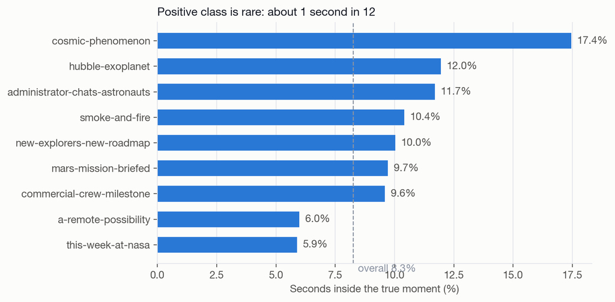

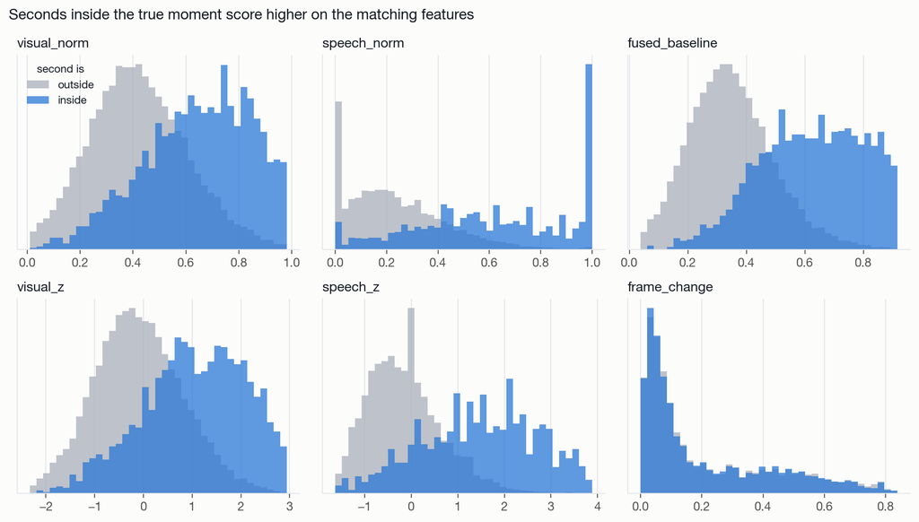

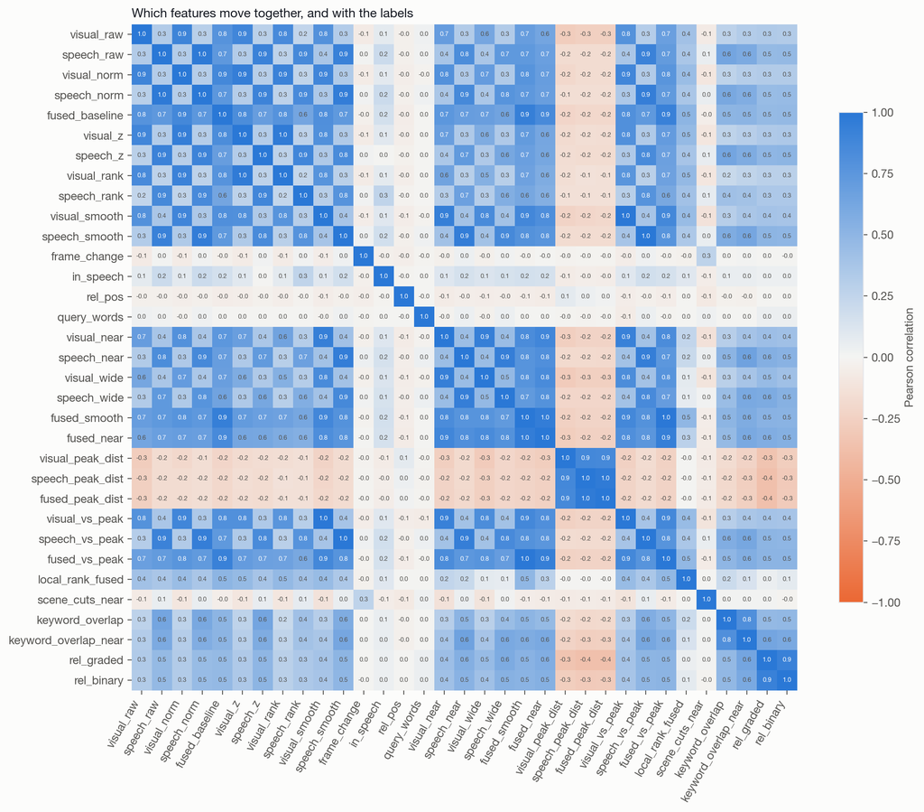

```python
show("01_class_balance.png", 650); show("02_feature_distributions.png"); show("03_correlation_heatmap.png", 760)
```

## 2. Models and protocol

| Task | Models |
| --- | --- |
| Regression | Ridge, Random forest, Gradient boosting (+ mean baseline) |
| Classification | Logistic regression, k-nearest neighbours, Gradient boosting (+ prior baseline) |

- **Leave-one-video-out:** each video is predicted by models trained on the other eight, so nothing leaks between neighbouring seconds or queries.
- **Hyper-parameters** are grid-searched inside each training split (grouped 3-fold CV). The **output-smoothing width** (a moving average of each model's per-second output over 1 to 15 s) and the classification **threshold** are also chosen on the training split only.
- Positives are rare (about 8%), so classifiers use class weights and are judged by precision, recall, F1 and PR-AUC, not accuracy.

```python
pd.read_csv(T / "best_params.csv").groupby(["task", "model"]).params.agg(lambda s: s.value_counts().index[0])
```

```
task            model
classification  gradient_boosting    {'model__learning_rate': 0.05, 'model__max_dep...
                knn                                        {'model__n_neighbors': 151}
                logistic                                             {'model__C': 0.1}
regression      gradient_boosting    {'model__learning_rate': 0.05, 'model__max_dep...
                random_forest        {'model__max_depth': 6, 'model__min_samples_le...
                ridge                                          {'model__alpha': 100.0}
Name: params, dtype: object
```

## 3. Regression

```python
reg = pd.read_csv(T / "regression_summary.csv")
reg[["model", "rmse_mean", "rmse_std", "mae_mean", "r2_mean", "spearman_mean"]].round(3)
```

|  | model | rmse_mean | rmse_std | mae_mean | r2_mean | spearman_mean |
| --- | --- | --- | --- | --- | --- | --- |
| 0 | dummy | 0.319 | 0.045 | 0.204 | -0.028 | 0.000 |
| 1 | gradient_boosting | 0.154 | 0.037 | 0.070 | 0.742 | 0.740 |
| 2 | random_forest | 0.154 | 0.037 | 0.069 | 0.744 | 0.854 |
| 3 | ridge | 0.198 | 0.030 | 0.129 | 0.588 | 0.696 |

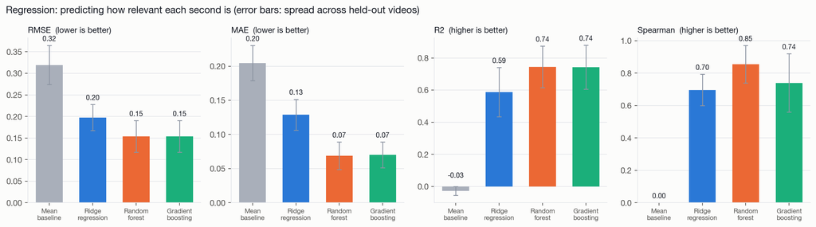

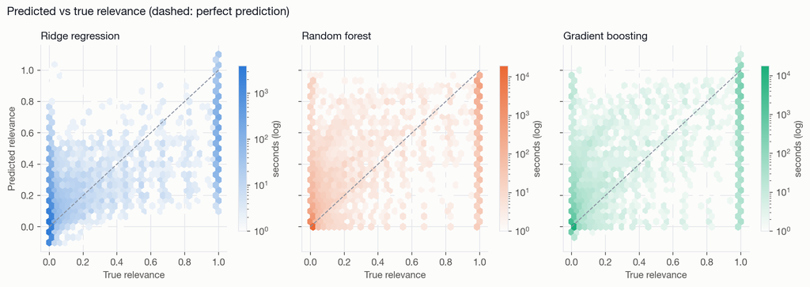

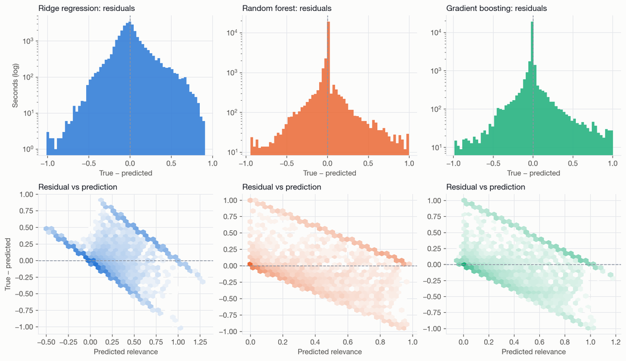

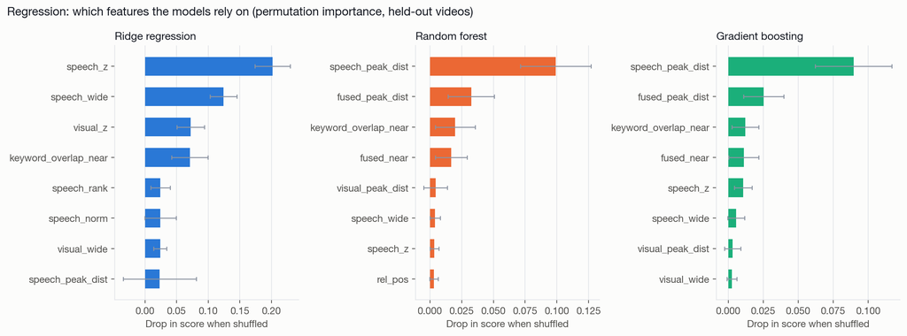

```python
show("05_reg_metrics.png", 1000); show("06_reg_pred_vs_actual.png", 1000); show("07_reg_residuals.png", 950); show("08_reg_importance.png", 1000)
```

**Reading.** Random forest and gradient boosting reach R² of about 0.74 and RMSE of 0.154 (mean baseline: R² −0.03, RMSE 0.32); ridge reaches 0.59. The two ensembles are indistinguishable, and both clearly beat the linear model, which means the relevance score has real non-linear structure once context features are present. The spread across held-out videos is wide (R² standard deviation about 0.13).

## 4. Classification

```python
cls = pd.read_csv(T / "classification_summary.csv")
cls[["model", "precision_mean", "recall_mean", "f1_mean", "balanced_accuracy_mean", "roc_auc_mean", "pr_auc_mean"]].round(3)
```

|  | model | precision_mean | recall_mean | f1_mean | balanced_accuracy_mean | roc_auc_mean | pr_auc_mean |
| --- | --- | --- | --- | --- | --- | --- | --- |
| 0 | dummy | 0.000 | 0.000 | 0.000 | 0.500 | 0.500 | 0.103 |
| 1 | gradient_boosting | 0.709 | 0.805 | 0.747 | 0.883 | 0.979 | 0.832 |
| 2 | knn | 0.688 | 0.820 | 0.743 | 0.888 | 0.975 | 0.812 |
| 3 | logistic | 0.728 | 0.811 | 0.761 | 0.887 | 0.978 | 0.845 |

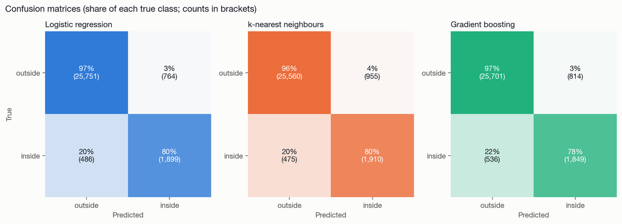

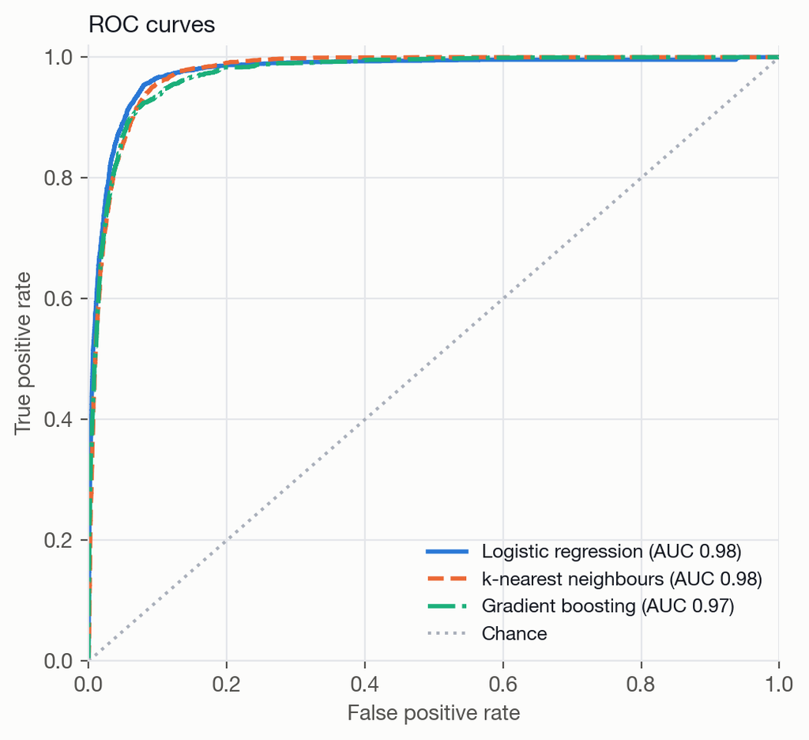

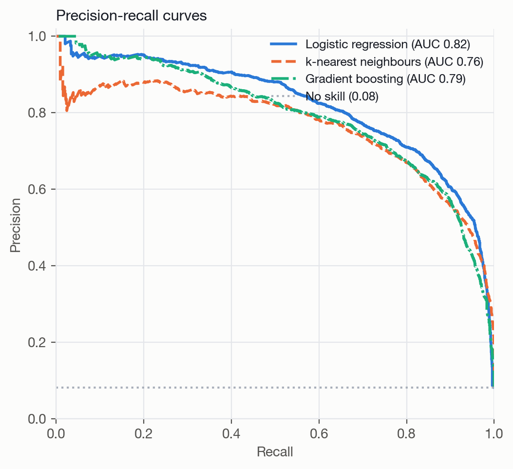

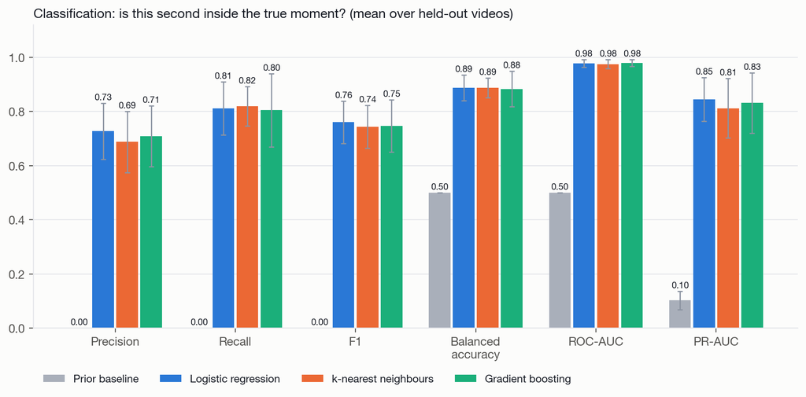

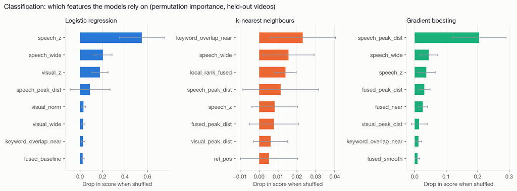

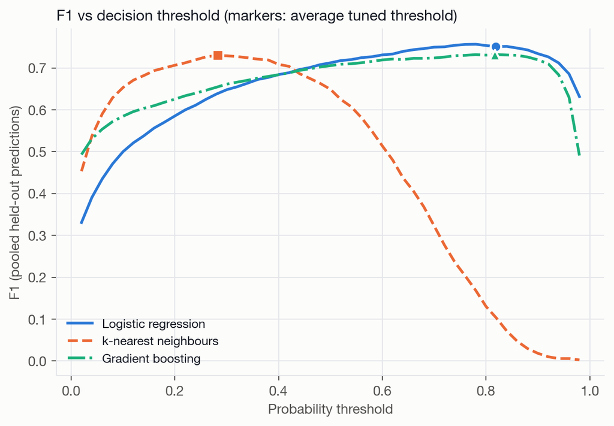

```python
show("10_cls_confusion.png", 1000); show("11_cls_roc.png", 520); show("12_cls_pr.png", 520); show("13_cls_metrics.png", 1000); show("14_cls_importance.png", 1000); show("15_cls_threshold_f1.png", 650)
```

**Reading.** All three classifiers are far above the prior baseline. Logistic regression is best by a small margin: F1 0.76, PR-AUC 0.85, balanced accuracy 0.89, ROC-AUC 0.98, with pooled accuracy 96%. About 81% of true seconds are found (recall) at about 73% precision. Plain accuracy is not the headline metric because always answering "no" already scores 91.7%. Permutation importance shows the models rely mostly on speech z-scores and on **distance to the speech peak**, plus the wider windows: context and per-video calibration carry the signal, not raw similarity.

## 5. What improved the models, and learning curves

```python
ab = pd.read_csv(T / "ablation.csv")
ab[ab.task == "regression"][["variant", "model", "rmse", "r2", "hit_at_1"]].round(3)
```

|  | variant | model | rmse | r2 | hit_at_1 |
| --- | --- | --- | --- | --- | --- |
| 0 | Original 15 features | ridge | 0.230 | 0.379 | 0.907 |
| 1 | Original 15 features | random_forest | 0.228 | 0.387 | 0.872 |
| 2 | Original 15 features | gradient_boosting | 0.226 | 0.401 | 0.907 |
| 6 | + context features | ridge | 0.203 | 0.512 | 0.884 |
| 7 | + context features | random_forest | 0.159 | 0.702 | 0.907 |
| 8 | + context features | gradient_boosting | 0.158 | 0.704 | 0.849 |
| 12 | + output smoothing | ridge | 0.197 | 0.543 | 0.930 |
| 13 | + output smoothing | random_forest | 0.154 | 0.720 | 0.919 |
| 14 | + output smoothing | gradient_boosting | 0.156 | 0.712 | 0.907 |

```python
ab[ab.task == "classification"][["variant", "model", "accuracy", "balanced_accuracy", "f1", "pr_auc", "hit_at_1"]].round(3)
```

|  | variant | model | accuracy | balanced_accuracy | f1 | pr_auc | hit_at_1 |
| --- | --- | --- | --- | --- | --- | --- | --- |
| 3 | Original 15 features | logistic | 0.941 | 0.797 | 0.636 | 0.704 | 0.907 |
| 4 | Original 15 features | knn | 0.930 | 0.779 | 0.585 | 0.618 | 0.907 |
| 5 | Original 15 features | gradient_boosting | 0.930 | 0.798 | 0.600 | 0.649 | 0.872 |
| 9 | + context features | logistic | 0.956 | 0.887 | 0.753 | 0.820 | 0.919 |
| 10 | + context features | knn | 0.948 | 0.873 | 0.712 | 0.761 | 0.919 |
| 11 | + context features | gradient_boosting | 0.952 | 0.876 | 0.731 | 0.792 | 0.919 |
| 15 | + output smoothing | logistic | 0.957 | 0.884 | 0.752 | 0.819 | 0.930 |
| 16 | + output smoothing | knn | 0.951 | 0.882 | 0.728 | 0.764 | 0.907 |
| 17 | + output smoothing | gradient_boosting | 0.953 | 0.872 | 0.733 | 0.791 | 0.919 |

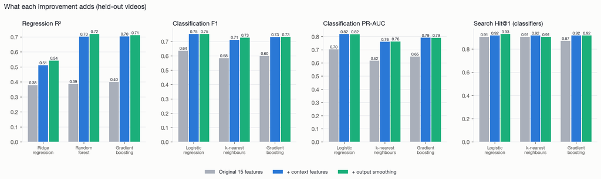

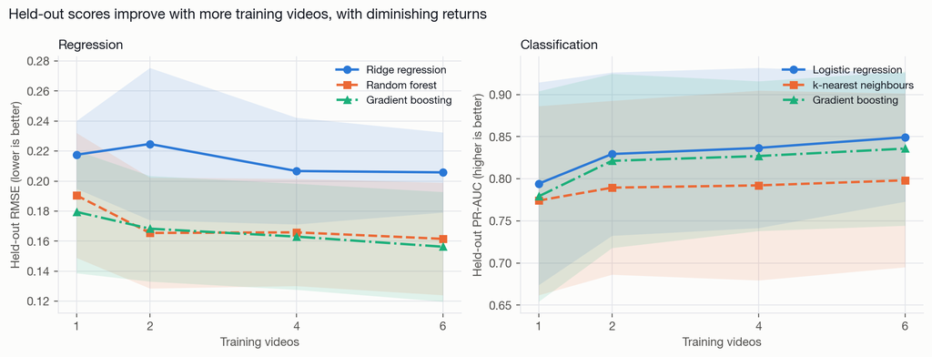

```python
show("19_ablation.png", 1100); show("09_learning_curves.png", 1000)
```

**Ablation.** The first two rows of each group are re-run from scratch, so they are directly comparable. The original 15 features give R² about 0.40 and F1 about 0.64. Adding the context features is what moves the numbers (R² to 0.70, F1 to 0.75, PR-AUC from 0.70 to 0.82). Smoothing the outputs adds a little more (R² +0.01 to +0.03, better search ranking). For regression every fold picked the widest smoothing option offered (15 s), so a wider option might help slightly.

## 6. Does it improve search?

Rank every second of a held-out query's video and check whether the true moment is on top. **Hit@k**: a true second is in the top k. **MRR**: 1 / rank of the first true second. Whiskers are 95% bootstrap intervals over the 86 queries.

```python
r = pd.read_csv(T / "retrieval.csv")
r[["method", "hit_at_1", "hit_at_1_lo", "hit_at_1_hi", "hit_at_5", "mrr", "n_queries"]].round(3)
```

|  | method | hit_at_1 | hit_at_1_lo | hit_at_1_hi | hit_at_5 | mrr | n_queries |
| --- | --- | --- | --- | --- | --- | --- | --- |
| 0 | Fixed-weight fusion | 0.872 | 0.802 | 0.942 | 0.965 | 0.913 | 86.0 |
| 1 | Picture only | 0.605 | 0.500 | 0.709 | 0.849 | 0.712 | 86.0 |
| 2 | Speech only | 0.895 | 0.826 | 0.953 | 0.919 | 0.913 | 86.0 |
| 3 | Regression: Ridge regression | 0.930 | 0.872 | 0.977 | 0.942 | 0.941 | 86.0 |
| 4 | Regression: Random forest | 0.919 | 0.849 | 0.965 | 0.942 | 0.930 | 86.0 |
| 5 | Regression: Gradient boosting | 0.907 | 0.837 | 0.965 | 0.942 | 0.924 | 86.0 |
| 6 | Classification: Logistic regression | 0.930 | 0.872 | 0.977 | 0.942 | 0.936 | 86.0 |
| 7 | Classification: k-nearest neighbours | 0.907 | 0.837 | 0.965 | 0.942 | 0.929 | 86.0 |
| 8 | Classification: Gradient boosting | 0.919 | 0.860 | 0.977 | 0.942 | 0.925 | 86.0 |
| 9 | Random | 0.082 | 0.066 | 0.098 | 0.372 | 0.231 | 86.0 |

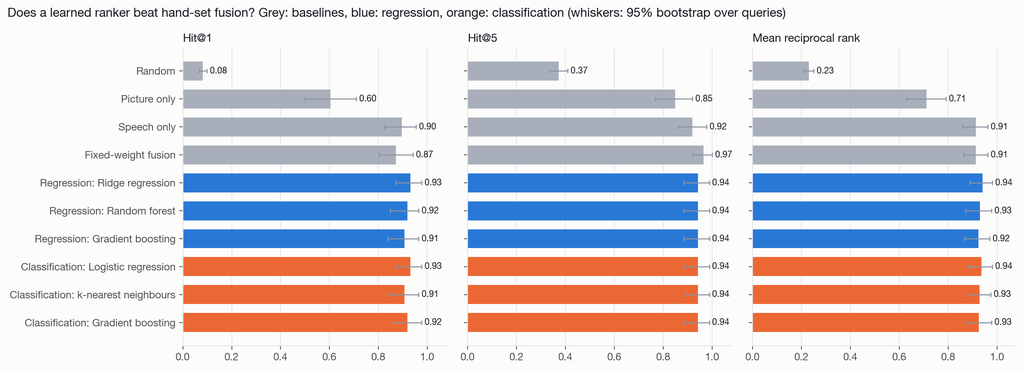

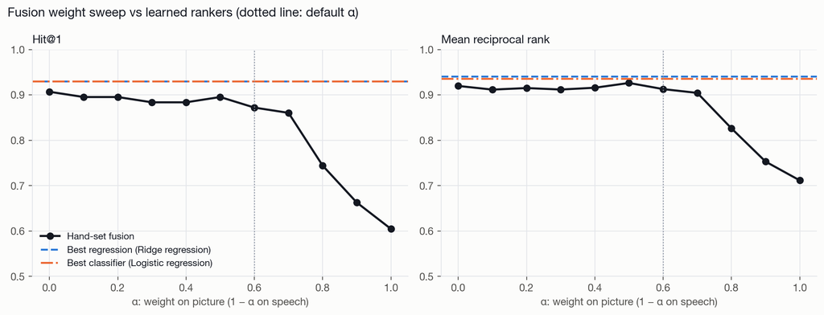

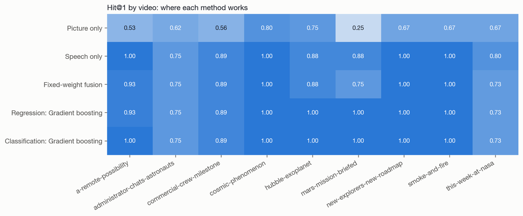

[figure not shown]

```python
show("16_retrieval_comparison.png", 1100); show("17_alpha_sweep.png", 1000); show("18_per_video_hit1.png", 1000); show("04_example_traces.png", 950)
```

**Reading.**

- Learned rankers put a true second first in 91 to 93% of queries, versus 87% for the hand-set fusion and 90% for speech only. They are ahead, but the 95% intervals (about ±0.07) still overlap, so **the improvement over hand-set fusion is consistent in direction but not statistically established** on 86 queries.
- Picture-only (0.60) is far worse than speech-only or any fusion. That is partly a labelling effect: intervals were written from transcripts. The α sweep shows fusion is flat for α ≤ 0.7 and degrades as picture dominates.
- The supervised models show the engineered features carry strong signal (R² 0.74, PR-AUC 0.85).

## 7. Limits

- 86 queries over 9 videos is small; every metric has wide intervals (R² varies by about ±0.13 across videos).
- Labels derive from transcripts, favouring the speech signal; a picture-labelled benchmark would likely favour picture and fusion.
- One content domain (NASA news). Results may not transfer to lectures, sports or silent footage.
- Positives are about 8% of seconds, so accuracy is not reported as a headline metric.